# Sentiment analysis and emotion modulation in sentences

Radu Chirila

12/18/2020

# Introduction

The human face plays an essential role in human communication. However, the ability to convey thoughts and ideas as speech is not the only function it holds. Facial expressions are a paramount aspect in communication as well, as they enable humans not only to transmit emotions in a more fluid way, but also to alter the meaning of spoken sentences[1]. Detecting these expressions is something hardcoded into the human brain. Through associations, humans are able to naturally understand complex sets of information such as intent, mood, sex, age, etc[2].  
However, since the rise of automation and innovations in fields like artificial intelligence and computer vision, algorithms capable of understanding social cues and facial expressions have seen an increased demand.  
Previous studies have determined two ways of tackling the problem of detecting expressions from image data: feature-based or template-based detection[3]. The first method uses landmarks for image segmentation. Features such as eyes and cheeks are detected in images and their relative position is computed[3]. Alternatively, template-based detection uses a standard general model of the human face and compares the input image against it in order to detect the displaced regions in the image and correlate them with certain emotions. For this method, both bidimensional and 3D models of the face can be used. However, in recent studies, an augmented version of a 3D face was used (with underlying facial muscles) in order to detect which muscles are relevant for emotion and which serve a supporting role in communication and basic physiology[3], [4].  
This study aims to explore an emotion modulation technique that links the perceived sentiment of a dataset of words into emotions, and subsequently applies a computational model to calculate the relative positions of a set of facial landmarks. This algorithm is intended to be used alongside a humanoid robot with actuated synthetic skin. Essentially, this study provides a basic understanding of the expressions a robot should exert when speaking. Two datasets were used in this report. The first one, “Emotions sensor dataset” (AndBrain.csv) is a collection of 1104 English words classified statistically into 7 basic human emotions: Disgust, Surprise, Anger, Sadness, Neutral, Happiness, Fear. The second dataset was created manually and consists of approximate positions of 7 facial landmarks that can be manipulated to obtain the 7 basic facial expressions described in the first dataset.

# Exploration of initial sentiment data

Exploring the word emotion dataset, it can be observed that each word in the dataset has a numeric result associated with each emotion. The table below shows the dataset.

| word | disgust | surprise | neutral | anger | sad | happy | fear |
| --- | --- | --- | --- | --- | --- | --- | --- |
| ability | 0.004464286 | 0.047831636 | 0.00063775515 | 0.023596939 | 0.013392858 | 0.015943877 | 0.04017858 |
| able | 1.7322194e-05 | 0.0001823925 | 0.00040859997 | 0.0001762788 | 0.0002190748 | 0.00024352966 | 0.00018646833 |
| abuse | 0.0005317264 | 0.00017724212 | 0.00017724212 | 0.13736264 | 0.0012406948 | 0.0015951791 | 0.002658632 |
| academy | 0.0071428576 | 0.021428574 | 0.0071428576 | 0.0071428576 | 0.0071428576 | 0.092857145 | 0.035714287 |
| accept | 0.008270677 | 0.0067669176 | 0.00075187976 | 0.048872184 | 0.018796993 | 0.024812032 | 0.038345866 |
| acceptance | 0.002747253 | 0.008241759 | 0.002747253 | 0.013736265 | 0.024725277 | 0.09065934 | 0.013736265 |
| accounting | 0.017857144 | 0.017857144 | 0.017857144 | 0.017857144 | 0.053571433 | 0.08928572 | 0.017857144 |
| accuracy | 0.035714287 | 0.107142866 | 0.035714287 | 0.035714287 | 0.035714287 | 0.035714287 | 0.035714287 |
| achieve | 0.0013824885 | 0.004147466 | 0.0004608295 | 0.0050691245 | 0.0069124424 | 0.12211982 | 0.0050691245 |
| acid | 0.017857144 | 0.017857144 | 0.017857144 | 0.017857144 | 0.125 | 0.017857144 | 0.017857144 |

[output cut: 1094 more lines]

The summary of this dataset unveiled that the numeric results are not consistent between emotions. The table below shows that there is no fixed maximum for the expressions recorded. Therefore, a classic normalization technique was employed in order to bring all the values from each expression in a range between 0 and 1. This procedure would enable the code to interpret the numerical values as percentages in the following computation steps.  
The normalization formula used was the following:  
$n_{normalized} = (n - range_{min}) * (bound_{max} - bound_{min})/(range_{max} - range_{min}) + bound_{min}$, where $bound_{min} = 0, bound_{max} = 1$ , $range_{min}$ and $range_{max}$ *are the minimum and maximum values of the numerical vector passed to the function*  
The summary of the initial data is:

```
##      word              disgust            surprise           neutral
##  Length:1104        Min.   :0.000002   Min.   :0.000003   Min.   :0.000032
##  Class :character   1st Qu.:0.002528   1st Qu.:0.015640   1st Qu.:0.000992
##  Mode  :character   Median :0.007937   Median :0.026907   Median :0.003968
##                     Mean   :0.012809   Mean   :0.032376   Mean   :0.008170
##                     3rd Qu.:0.017857   3rd Qu.:0.041245   3rd Qu.:0.011905
##                     Max.   :0.139456   Max.   :0.135056   Max.   :0.035714
##      anger               sad               happy               fear
##  Min.   :0.000003   Min.   :0.000003   Min.   :0.000003   Min.   :0.000003
##  1st Qu.:0.011905   1st Qu.:0.011905   1st Qu.:0.015306   1st Qu.:0.014286
##  Median :0.023810   Median :0.023810   Median :0.027778   Median :0.026316
##  Mean   :0.028224   Mean   :0.027243   Mean   :0.033701   Mean   :0.030917
##  3rd Qu.:0.035714   3rd Qu.:0.035714   3rd Qu.:0.042857   3rd Qu.:0.038462
##  Max.   :0.137363   Max.   :0.125000   Max.   :0.137363   Max.   :0.140538
```

The normalized data then becomes:

```
##      word              disgust          surprise        neutral
##  Length:1104        Min.   :0.0000   Min.   :0.000   Min.   :0.0000
##  Class :character   1st Qu.:0.0181   1st Qu.:0.116   1st Qu.:0.0269
##  Mode  :character   Median :0.0569   Median :0.199   Median :0.1103
##                     Mean   :0.0918   Mean   :0.240   Mean   :0.2281
##                     3rd Qu.:0.1280   3rd Qu.:0.305   3rd Qu.:0.3327
##                     Max.   :1.0000   Max.   :1.000   Max.   :1.0000
##      anger             sad             happy            fear
##  Min.   :0.0000   Min.   :0.0000   Min.   :0.000   Min.   :0.000
##  1st Qu.:0.0867   1st Qu.:0.0952   1st Qu.:0.111   1st Qu.:0.102
##  Median :0.1733   Median :0.1905   Median :0.202   Median :0.187
##  Mean   :0.2054   Mean   :0.2179   Mean   :0.245   Mean   :0.220
##  3rd Qu.:0.2600   3rd Qu.:0.2857   3rd Qu.:0.312   3rd Qu.:0.274
##  Max.   :1.0000   Max.   :1.0000   Max.   :1.000   Max.   :1.000
```

## Analysing extremes

[figure not shown]

| word | disgust | surprise | neutral | anger | sad | happy | fear | Average |
| --- | --- | --- | --- | --- | --- | --- | --- | --- |
| porno | 1.00000000 | 0.02515988 | 0.09442410 | 0.02473896 | 0.02718661 | 0.02473966 | 0.02417914 | 0.17435 |
| amazing | 0.00021704 | 1.00000000 | 0.00000000 | 0.00441702 | 0.00536844 | 0.03853987 | 0.00934188 | 0.15113 |
| accuracy | 0.25608778 | 0.79331544 | 1.00000000 | 0.25998259 | 0.28569647 | 0.25998313 | 0.25410761 | 0.44417 |
| abuse | 0.00379975 | 0.00128684 | 0.00406756 | 1.00000000 | 0.00990085 | 0.01159036 | 0.01889412 | 0.14993 |
| acid | 0.12803731 | 0.13219795 | 0.49955017 | 0.12997953 | 1.00000000 | 0.12998016 | 0.12704188 | 0.30668 |
| compatible | 0.00786686 | 0.02438494 | 0.02989723 | 0.00797666 | 0.02634933 | 1.00000000 | 0.00779557 | 0.15775 |
| nuclear | 0.01661676 | 0.00340883 | 0.01209901 | 0.00335317 | 0.00368571 | 0.00335389 | 1.00000000 | 0.14893 |

Observing the data in the table above, it can be seen that “accuracy” and “acid” have a dominant expression and a second relatively high expression. This could be due to the two moods being confused by the people tested, or could represent that the two expressions are correlated.  
Hence, the relationship between **neutral** and **sad** and between **neutral** and **surprise** can be tested further to gain additional information between a typical person’s perception regarding these expressions.  
Firstly, a series of Welch two-sample T-Tests were performed, assuming non-paired samples and confidence interval of 95%.  
Null Hypothesis: The means of the two emotions tested are equal, i.e $\mu_{1} - \mu_{2} = 0$.  
Alternate Hypothesis: The means of the two emotions tested are not equal.  
The p-value is the probability that the difference between the sample means is at least as large as what has been observed, under the assumption that the population means are equal. The smaller the p-value, the lower the probability of observing a difference in sample means. Therefore, the smaller the p-value, the stronger the evidence is that the two populations have different means.

```
## [1] "T-test between neutral and surprise: 0.250618 , alpha = 0.05"
```

```
## [1] "T-test between neutral and sad: 0.308675 , alpha = 0.05"
```

Since both the p-values are larger than the significance level, the Null Hypothesis is accepted.  
Next, a correlation test over all the expressions is performed, providing additional insight into the data collected.

|  | disgust | surprise | neutral | anger | sad | happy | fear |
| --- | --- | --- | --- | --- | --- | --- | --- |
| disgust | 1.000000 | 0.149072 | 0.557045 | 0.142729 | 0.150864 | 0.049825 | 0.148948 |
| surprise | 0.149072 | 1.000000 | 0.396969 | -0.017968 | 0.104156 | -0.065244 | 0.043478 |
| neutral | 0.557045 | 0.396969 | 1.000000 | 0.259740 | 0.370187 | 0.181255 | 0.312440 |
| anger | 0.142729 | -0.017968 | 0.259740 | 1.000000 | 0.038070 | -0.118633 | -0.058962 |
| sad | 0.150864 | 0.104156 | 0.370187 | 0.038070 | 1.000000 | -0.085120 | 0.070484 |
| happy | 0.049825 | -0.065244 | 0.181255 | -0.118633 | -0.085120 | 1.000000 | -0.106338 |
| fear | 0.148948 | 0.043478 | 0.312440 | -0.058962 | 0.070484 | -0.106338 | 1.000000 |

# Action sets for each expression

In order to modulate robotic facial expressions, certain actuation points on the face must be set. Hence, quantifying facial expressions was done after studying the 7 moods depicted in the “Emotion sensor dataset”. The figure below shows an overview of these moods. The 3D facial expressions used in this study were generated using a 3D modelling and rigging software (Blender + the makehuman plugin).

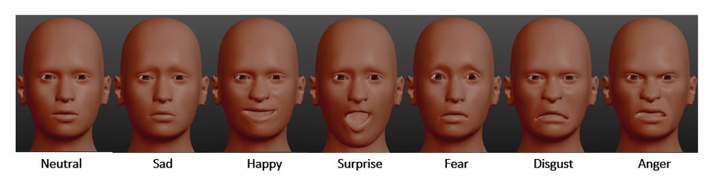

The expression kinematics were used to create a simplified theoretical model, able to manipulate key facial points in order to achieve the 7 basic emotions. The facial landmarks were chosen visually, based on the areas where the most movement was observed.  
Therefore the landmarks were: * eyebrows - pair, cheeks - pair, mouth extremities - pair, Menton point - singular. The Menton point lays in the mandibular plane and in the context of this study it is used to describe whether the mouth is open and if so by how much. A visual representation of these points can be seen in the figure below.

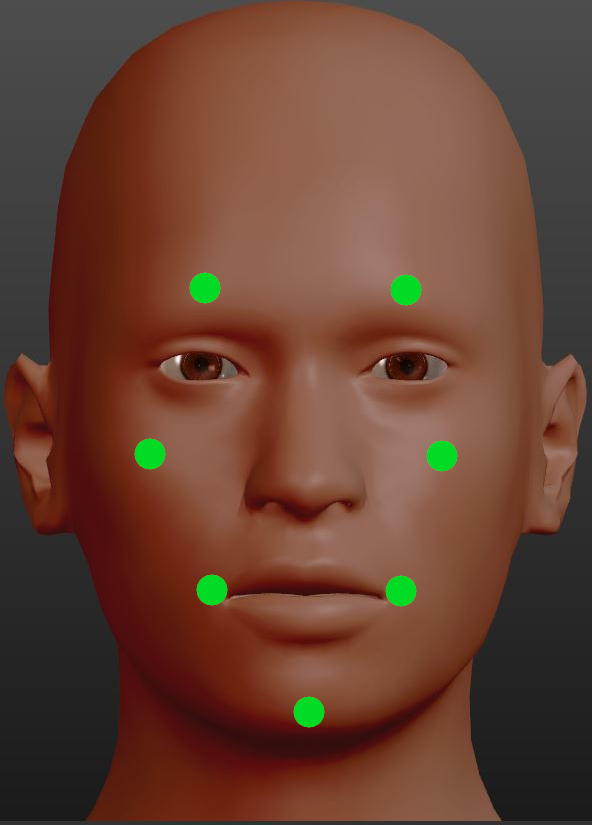

Each landmark’s position is defined only on the vertical axis in this study, and the available positions a landmark can take are between -0.5 to 0.5.  
$Z_{coord_{landmark}} \in [-0.5, 0.5].$  
The landmark positions need to be centered around 0. As a default, the *neutral* emotion sets all the landmarks to a position of 0. A positive value for a specific landmark corresponds to a raised position, while a negative value corresponds to a lowered position, *relative to the *neutral* emotion coordinates*. The numerical values of the positions can be observed in the table below:

| Expression | Eyebrow_1 | Eyebrow_2 | Cheekbone_1 | Cheekbone_2 | Mouth_corner_1 | Mouth_corner_2 | Menton |
| --- | --- | --- | --- | --- | --- | --- | --- |
| neutral | 0.0 | 0.0 | 0.0 | 0.0 | 0.0 | 0.0 | 0.0 |
| happy | 0.1 | 0.1 | 0.5 | 0.5 | 0.3 | 0.3 | -0.2 |
| sad | 0.2 | 0.2 | 0.0 | 0.0 | -0.2 | -0.2 | 0.1 |
| surprise | 0.1 | 0.1 | 0.1 | 0.1 | 0.2 | 0.2 | -0.5 |
| fear | 0.4 | 0.4 | 0.1 | 0.1 | -0.2 | -0.2 | -0.2 |
| disgust | -0.3 | -0.3 | 0.3 | 0.3 | -0.3 | -0.3 | 0.5 |
| anger | -0.4 | -0.4 | 0.3 | 0.3 | -0.3 | -0.3 | -0.3 |

| word | disgust | surprise | neutral | anger | sad | happy | fear | Expression | Eyebrow_1 | Eyebrow_2 | Cheekbone_1 | Cheekbone_2 | Mouth_corner_1 | Mouth_corner_2 | Menton |
| --- | --- | --- | --- | --- | --- | --- | --- | --- | --- | --- | --- | --- | --- | --- | --- |
| ability | 0.0319994520672939 | 0.354144529891276 | 0.0169735242500052 | 0.171766224765874 | 0.10712058378778 | 0.116051262096028 | 0.285874096518055 | surprise | 0.000192633459036769 | 0.000192633459036769 | 0.00427872314195452 | 0.00427872314195452 | 0.000203161797589791 | 0.000203161797589791 | -0.00539791803408364 |
| able | 0.000111047299768955 | 0.00132497762147461 | 0.0105514067510868 | 0.00125980986740084 | 0.00172768829617785 | 0.00175012878727428 | 0.0013029870432767 | neutral | 1.48552879904402e-05 | 1.48552879904402e-05 | 7.3823507933312e-06 | 7.3823507933312e-06 | -1.27030584311424e-05 | -1.27030584311424e-05 | -1.12704883999669e-06 |
| abuse | 0.00379975048033297 | 0.00128684155399183 | 0.00406755900652715 | 1 | 0.00990085224289668 | 0.0115903609479051 | 0.0188941151182384 | anger | -0.000171093837341708 | -0.000171093837341708 | 0.000135713663893659 | 0.000135713663893659 | -0.000127081465184722 | -0.000127081465184722 | -0.000147101066836695 |
| academy | 0.0512070235938153 | 0.15864265348915 | 0.199280257514348 | 0.0519776959198063 | 0.0571193328958058 | 0.675992612978263 | 0.254107611604394 | happy | 0.00327186581580704 | 0.00327186581580704 | 0.0579904272670721 | 0.0579904272670721 | 0.0118014373252402 | 0.0118014373252402 | -0.0115499213555056 |
| accept | 0.059294420546168 | 0.0500801944318164 | 0.0201718881488193 | 0.355774334436094 | 0.150354742619049 | 0.180612901714995 | 0.2728330883154 | anger | -0.00248237444065544 | -0.00248237444065544 | 0.00474951807027379 | 0.00474951807027379 | -0.00387466535898582 | -0.00387466535898582 | -0.00471004241977304 |
| acceptance | 0.0196869067685617 | 0.0610006801351616 | 0.0760926026684633 | 0.099978830308796 | 0.197782198086552 | 0.659992227964383 | 0.0977190178684765 | happy | 0.00285128357323055 | 0.00285128357323055 | 0.011110778479287 | 0.011110778479287 | -0.00015310736145897 | -0.00015310736145897 | -0.00372707207561549 |
| accounting | 0.128037309699901 | 0.132197945430712 | 0.499550171455913 | 0.129979534751808 | 0.428557204664954 | 0.649992046482056 | 0.127041878304501 | happy | 0.0619871068592709 | 0.0619871068592709 | 0.114503766891361 | 0.114503766891361 | -0.0778336760012502 | -0.0778336760012502 | 0.0306121437252023 |
| accuracy | 0.256087779372551 | 0.793315439565239 | 1 | 0.259982592191639 | 0.285696471830343 | 0.25998312678933 | 0.254107611604394 | neutral | 0.156367748528653 | 0.156367748528653 | 0.32960825689129 | 0.32960825689129 | -0.0160696332716398 | -0.0160696332716398 | -0.225500849388694 |
| achieve | 0.00990041767467027 | 0.0306844249962656 | 0.0120151492620494 | 0.0368805640149893 | 0.0552759652978575 | 0.889029741629822 | 0.036046410820098 | happy | 4.03393367183643e-05 | 4.03393367183643e-05 | 0.00114497253019249 | 0.00114497253019249 | 0.000326107914377349 | 0.000326107914377349 | -0.000158471715426227 |
| acid | 0.128037309699901 | 0.132197945430712 | 0.499550171455913 | 0.129979534751808 | 1 | 0.129980163265309 | 0.127041878304501 | sad | 0.199047192301227 | 0.199047192301227 | 0.0460189189164497 | 0.0460189189164497 | -0.176858889435338 | -0.176858889435338 | 0.0221794464870586 |

[output cut: 1094 more lines]

# Analysis of simple sentences and validation of results

Modulating a robot’s facial expressions during a conversation with a user can greatly improve on the user’s empathic reception of the robot[5]. It is important that the expression of the robot matches the expected one from the user[2]. In order to test this, a random sentence was generated. At this stage, this sentence does not need to make any kind of sense, but it should be constructed in a simple enough manner. Arbitrarily, the construction was chosen to be the following:  
**The *[random word]* is *[second random word]* and *[third random word]*.**  
Since the random words are chosen from the dataset, anything can happen to the overall valence of the sentence, therefore, this aspect was disregarded for the sake of result validation accuracy. It is also important to note that prepositions, simple verbs and articles are not present in the dataset and they generally do not hold any emotion – they are simply used to create and structure sentences. Therefore, words such as “the”, “and”, “is” are assigned the “neutral” emotion by default.

**Random sentence: The prime is gaming and managed .**

Time-series result for the random sentence: neutral, sad, neutral, surprise, neutral, surprise  
Time series positions of each landmark for the random sentence:

| Eyebrow_1 | Eyebrow_2 | Cheekbone_1 | Cheekbone_2 | Mouth_corner_1 | Mouth_corner_2 | Menton | Dominant_Mood |
| --- | --- | --- | --- | --- | --- | --- | --- |
| 0.0000000 | 0.0000000 | 0.0000000 | 0.0000000 | 0.0000000 | 0.0000000 | 0.00000000 | neutral |
| 0.03126281 | 0.03126281 | 0.04690239 | 0.04690239 | -0.01887117 | -0.01887117 | -0.00002507 | sad |
| 0.0000000 | 0.0000000 | 0.0000000 | 0.0000000 | 0.0000000 | 0.0000000 | 0.00000000 | neutral |
| 0.00587517 | 0.00587517 | 0.02454465 | 0.02454465 | 0.00195959 | 0.00195959 | -0.04740961 | surprise |
| 0.0000000 | 0.0000000 | 0.0000000 | 0.0000000 | 0.0000000 | 0.0000000 | 0.00000000 | neutral |
| 0.00206637 | 0.00206637 | 0.00605278 | 0.00605278 | 0.00210701 | 0.00210701 | -0.00353454 | surprise |

# Conclusions

This study devised a way to compute facial landmark positions in order to modulate emotions from sentences in English. The main application intended for this algorithm is controlling a humanoid robot with a soft-actuated face and making it exert emotions when interacting to a user in order to generate an empathic response. However, sentiment analysis strategies have a wide range of uses, and a similar algorithm could possibly be used to analyse the overall sentiment of news articles and drive a stock trading algorithm based on the computed emotions. Future development of this program could enable it to control a 3D model of a human face in real time and emulate the emotion time-series data and test for quality of user interaction and empathic response.

# References

[1] M. G. Frank, “Facial Expressions,” Int. Encycl. Soc. Behav. Sci., pp. 5230–5234, 2001, doi: 10.1016/b0-08-043076-7/01713-7.  
[2] D. N. Albohn and R. B. Adams, Social Vision: At the Intersection of Vision and Person Perception. Elsevier Inc., 2016.  
[3] N. Alugupally, A. Samal, D. Marx, and S. Bhatia, “Analysis of landmarks in recognition of face expressions,” Pattern Recognit. Image Anal., vol. 21, no. 4, pp. 681–693, 2011, doi: 10.1134/S105466181104002X.  
[4] M. Wang, D. Bradley, S. Zafeiriou, and T. Beeler, “Facial Expression Synthesis using a Global-Local Multilinear Framework,” Comput. Graph. Forum, vol. 39, no. 2, 2020, doi: 10.1111/cgf.13926.  
[5] A. M. Rosenthal-von der Pütten, N. C. Krämer, L. Hoffmann, S. Sobieraj, and S. C. Eimler, “An Experimental Study on Emotional Reactions Towards a Robot,” Int. J. Soc. Robot., vol. 5, no. 1, pp. 17–34, 2013, doi: 10.1007/s12369-012-0173-8.